# MEGALECTRICS 2020 SALES REPORT

## Powered By (Marketing Department)

# Contents

### 2020 MONTHLY SALES

### 2020 QUARTERLY SALES

### 2020 SALES BY LOCATIONS

### 2020 AVERAGE SALES PER YEAR

### Conclusion

## Report Overview

> This is to report the Megalectrics sales for the year of 2020

## 2020 MONTHLY SALES

> We visualized each sale by month and each station across the board. Our observation was that out of all the stations across the board CLASSIC FM Lagos was outstanding, followed by BEAT FM Lagos. The remaining stations have fairly sales throughout each month. In some months stations like NAIJA FM Lagos, NAIJA FM PH and LAGOSTALKS FM fair more than other stations apart from CLASSIC FM Lagos and BEAT FM Lagos.

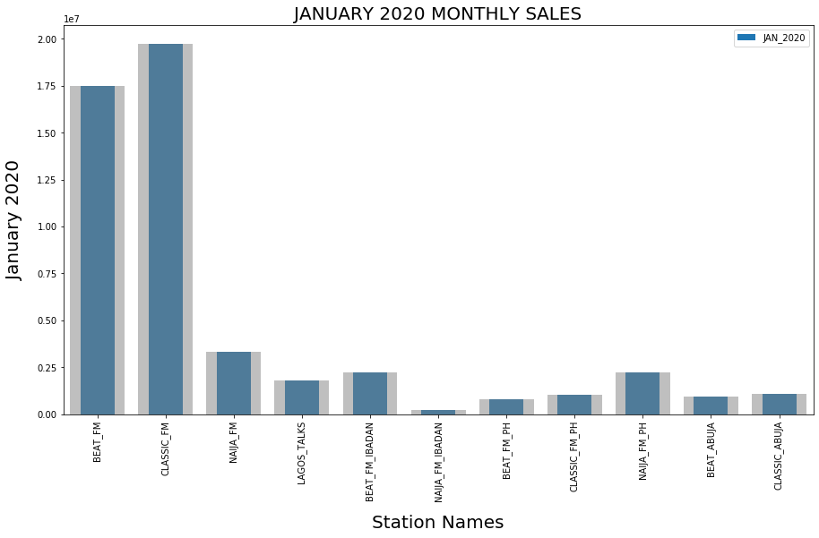

```python
sales2020.plot.bar(x="STATION_NAMES", y="JAN_2020", figsize = (15,8));
plt.bar(sales2020['STATION_NAMES'], sales2020['JAN_2020'], color = 'grey', alpha = 0.5);
plt.title('JANUARY 2020 MONTHLY SALES', fontsize = 20);
plt.xlabel('Station Names', fontsize = 20, labelpad=15);
plt.ylabel('January 2020', fontsize = 20, labelpad=15);
```

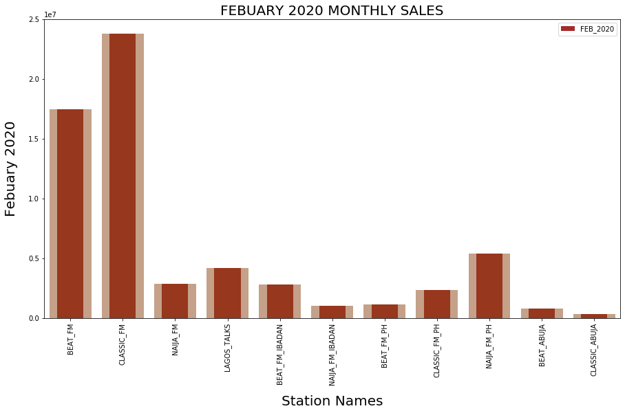

```python
sales2020.plot.bar(x="STATION_NAMES", y="FEB_2020", figsize = (15,8), color = 'brown');
plt.bar(sales2020['STATION_NAMES'], sales2020['FEB_2020'], color = 'saddlebrown', alpha = 0.5);
plt.title('FEBUARY 2020 MONTHLY SALES', fontsize = 20);
plt.xlabel('Station Names', fontsize = 20, labelpad=15);
plt.ylabel('Febuary 2020', fontsize = 20, labelpad=15);
```

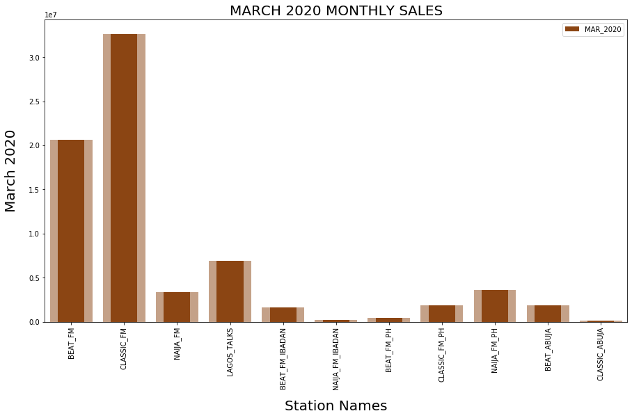

```python
sales2020.plot.bar(x="STATION_NAMES", y="MAR_2020", figsize = (15,8), color = 'saddlebrown');
plt.bar(sales2020['STATION_NAMES'], sales2020['MAR_2020'], color = 'saddlebrown', alpha = 0.5);
plt.title('MARCH 2020 MONTHLY SALES', fontsize = 20);
plt.xlabel('Station Names', fontsize = 20, labelpad=15);
plt.ylabel('March 2020', fontsize = 20, labelpad=15);
```

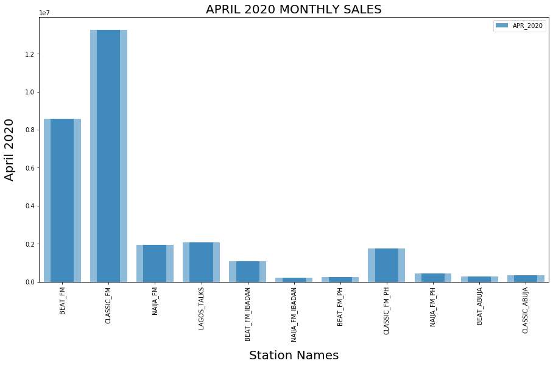

```python
sales2020.plot.bar(x="STATION_NAMES", y="APR_2020", figsize = (15,8), alpha = 0.7);
plt.bar(sales2020['STATION_NAMES'], sales2020['APR_2020'], alpha = 0.5);
plt.title('APRIL 2020 MONTHLY SALES', fontsize = 20);
plt.xlabel('Station Names', fontsize = 20, labelpad=15);
plt.ylabel('April 2020', fontsize = 20, labelpad=15);
```

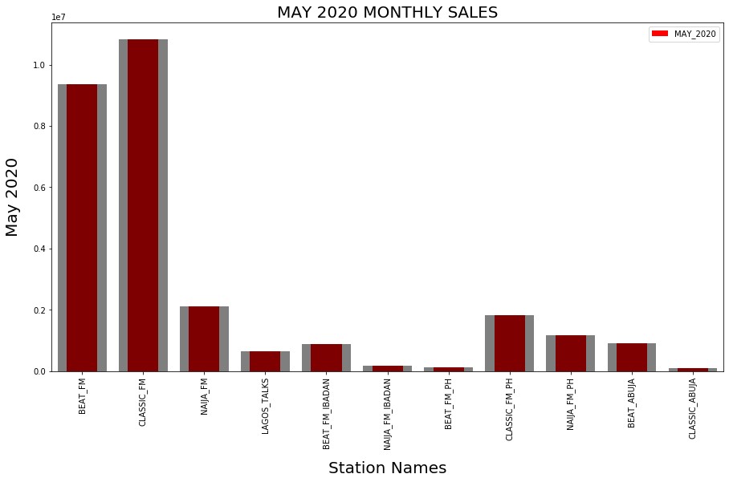

```python
sales2020.plot.bar(x="STATION_NAMES", y="MAY_2020", figsize = (15,8),  color = 'red');
plt.bar(sales2020['STATION_NAMES'], sales2020['MAY_2020'],color = 'black', alpha = 0.5);
plt.title('MAY 2020 MONTHLY SALES', fontsize = 20);
plt.xlabel('Station Names', fontsize = 20, labelpad=15);
plt.ylabel('May 2020', fontsize = 20, labelpad=15);
```

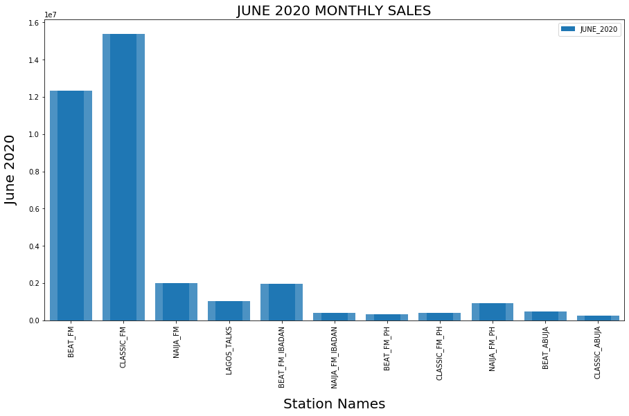

```python
sales2020.plot.bar(x="STATION_NAMES", y="JUNE_2020", figsize = (15,8));
plt.bar(sales2020['STATION_NAMES'], sales2020['JUNE_2020'], alpha = 0.8);
plt.title('JUNE 2020 MONTHLY SALES', fontsize = 20);
plt.xlabel('Station Names', fontsize = 20, labelpad=15);
plt.ylabel('June 2020', fontsize = 20, labelpad=15);
```

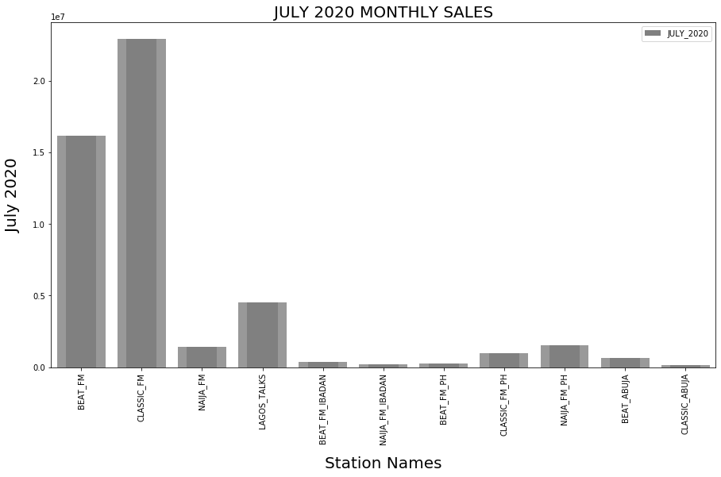

```python
sales2020.plot.bar(x="STATION_NAMES", y="JULY_2020", figsize = (15,8), color = 'grey');
plt.bar(sales2020['STATION_NAMES'], sales2020['JULY_2020'], color = 'grey', alpha = 0.8);
plt.title('JULY 2020 MONTHLY SALES', fontsize = 20);
plt.xlabel('Station Names', fontsize = 20, labelpad=15);
plt.ylabel('July 2020', fontsize = 20, labelpad=15);
```

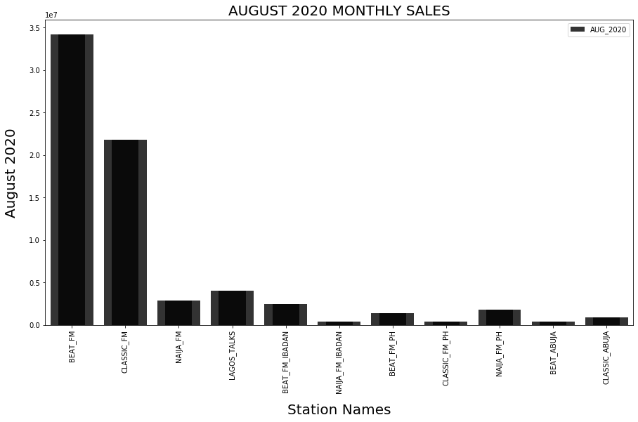

```python
sales2020.plot.bar(x="STATION_NAMES", y="AUG_2020", figsize = (15,8),color = 'black', alpha = 0.8);
plt.bar(sales2020['STATION_NAMES'], sales2020['AUG_2020'], color = 'black', alpha = 0.8);
plt.title('AUGUST 2020 MONTHLY SALES', fontsize = 20);
plt.xlabel('Station Names', fontsize = 20, labelpad=15);
plt.ylabel('August 2020', fontsize = 20, labelpad=15);
```

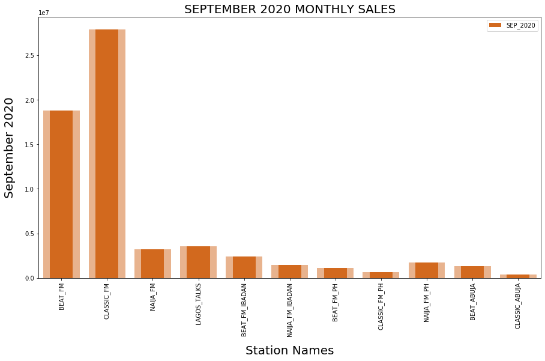

```python
sales2020.plot.bar(x="STATION_NAMES", y="SEP_2020", figsize = (15,8), color = 'chocolate');
plt.bar(sales2020['STATION_NAMES'], sales2020['SEP_2020'], color = 'chocolate', alpha = 0.5);
plt.title('SEPTEMBER 2020 MONTHLY SALES', fontsize = 20);
plt.xlabel('Station Names', fontsize = 20, labelpad=15);
plt.ylabel('September 2020', fontsize = 20, labelpad=15);
```

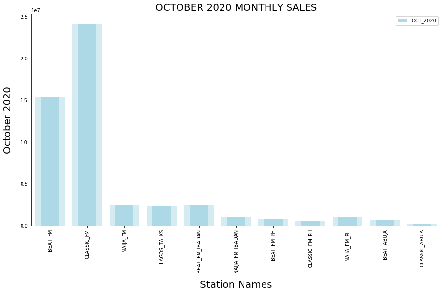

```python
sales2020.plot.bar(x="STATION_NAMES", y="OCT_2020", figsize = (15,8), color = 'lightblue');
plt.bar(sales2020['STATION_NAMES'], sales2020['OCT_2020'], color = 'lightblue', alpha = 0.5);
plt.title('OCTOBER 2020 MONTHLY SALES', fontsize = 20);
plt.xlabel('Station Names', fontsize = 20, labelpad=15);
plt.ylabel('October 2020', fontsize = 20, labelpad=15);
```

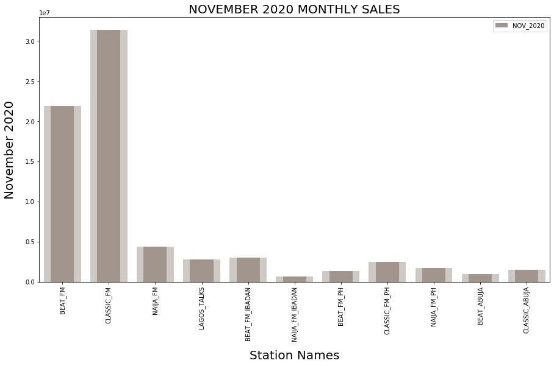

```python
sales2020.plot.bar(x="STATION_NAMES", y="NOV_2020", figsize = (15,8), color = '#a1958e');
plt.bar(sales2020['STATION_NAMES'], sales2020['NOV_2020'], color = '#a1958e', alpha = 0.5);
plt.title('NOVEMBER 2020 MONTHLY SALES', fontsize = 20);
plt.xlabel('Station Names', fontsize = 20, labelpad=15);
plt.ylabel('November 2020', fontsize = 20, labelpad=15);
```

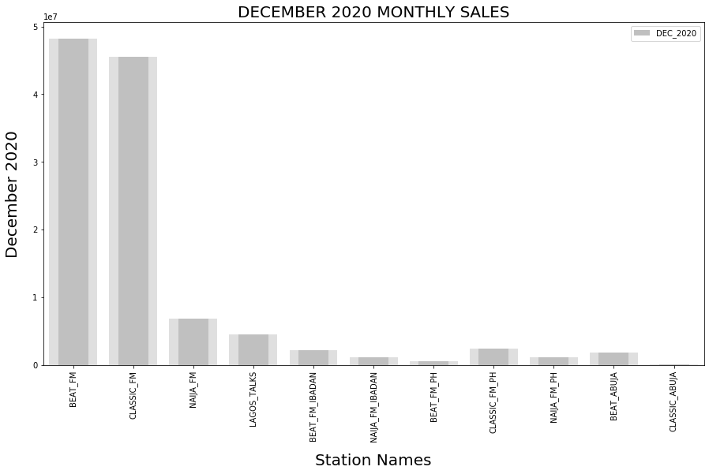

```python
sales2020.plot.bar(x="STATION_NAMES", y="DEC_2020", figsize = (15,8), color = 'silver');
plt.bar(sales2020['STATION_NAMES'], sales2020['DEC_2020'], color = 'silver', alpha = 0.5);
plt.title('DECEMBER 2020 MONTHLY SALES', fontsize = 20);
plt.xlabel('Station Names', fontsize = 20, labelpad=15);
plt.ylabel('December 2020', fontsize = 20, labelpad=15);
```

## 2020 QUARTERLY SALES

> For Quarterly sales, we visualized each sale by 1st, 2nd, 3rd, and 4th quarter for each station across the board. Our observation was that out of all the stations across the board CLASSIC FM Lagos was outstanding throughout all the Quarters, followed by BEAT FM Lagos. The remaining stations have fairly sales throughout each quarter.

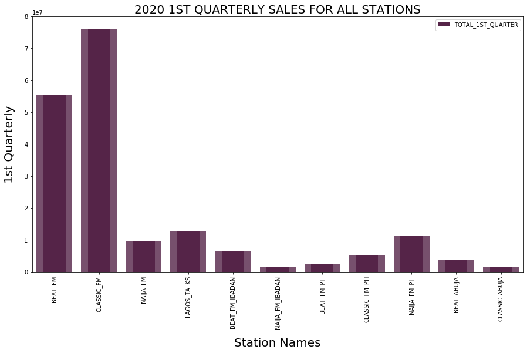

```python
sales2020.plot.bar(x="STATION_NAMES", y="TOTAL_1ST_QUARTER", figsize = (15,8), color = '#552448');
plt.bar(sales2020['STATION_NAMES'], sales2020['TOTAL_1ST_QUARTER'], color = '#552448', alpha = 0.8);
plt.title('2020 1ST QUARTERLY SALES FOR ALL STATIONS', fontsize = 20);
plt.xlabel('Station Names', fontsize = 20, labelpad=15);
plt.ylabel('1st Quarterly', fontsize = 20, labelpad=15);
```

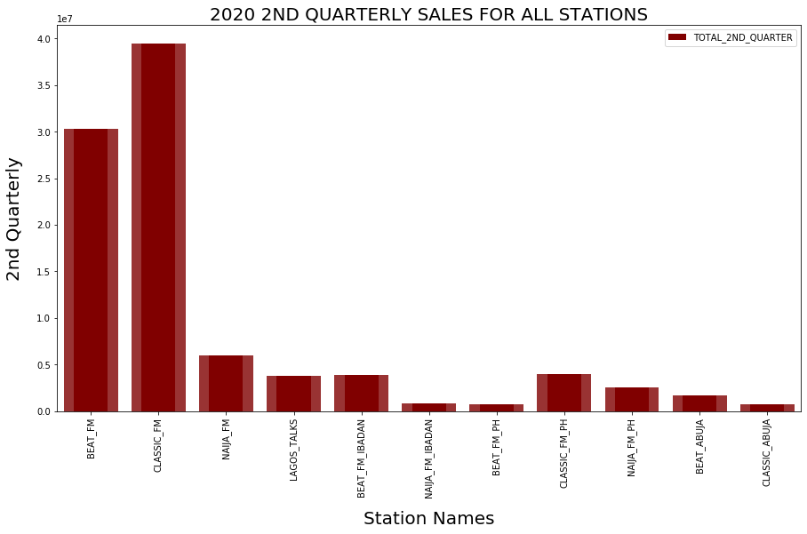

```python
sales2020.plot.bar(x="STATION_NAMES", y="TOTAL_2ND_QUARTER", figsize = (15,8), color = 'maroon');
plt.bar(sales2020['STATION_NAMES'], sales2020['TOTAL_2ND_QUARTER'], color = 'maroon', alpha = 0.8);
plt.title('2020 2ND QUARTERLY SALES FOR ALL STATIONS', fontsize = 20);
plt.xlabel('Station Names', fontsize = 20, labelpad=15);
plt.ylabel('2nd Quarterly', fontsize = 20, labelpad=15);
```

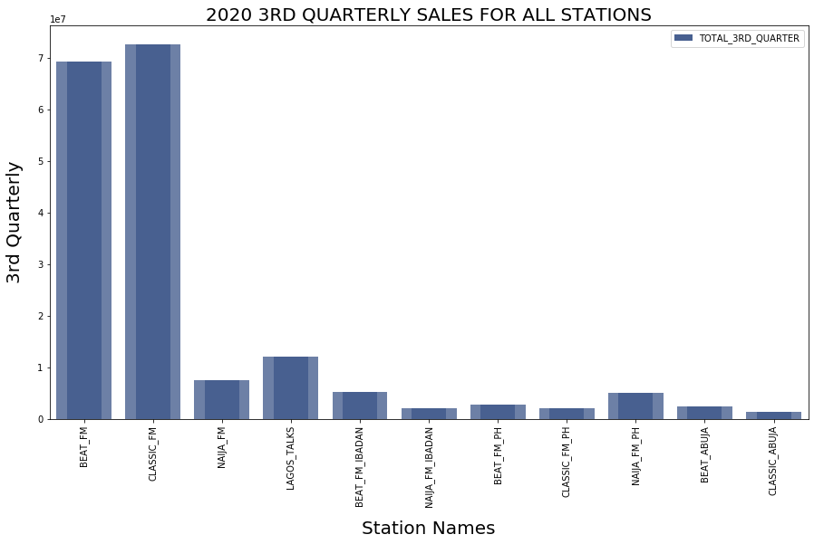

```python
sales2020.plot.bar(x="STATION_NAMES", y="TOTAL_3RD_QUARTER", figsize = (15,8), color = '#486090');
plt.bar(sales2020['STATION_NAMES'], sales2020['TOTAL_3RD_QUARTER'], color = '#486090', alpha = 0.8);
plt.title('2020 3RD QUARTERLY SALES FOR ALL STATIONS', fontsize = 20);
plt.xlabel('Station Names', fontsize = 20, labelpad=15);
plt.ylabel('3rd Quarterly', fontsize = 20, labelpad=15);
```

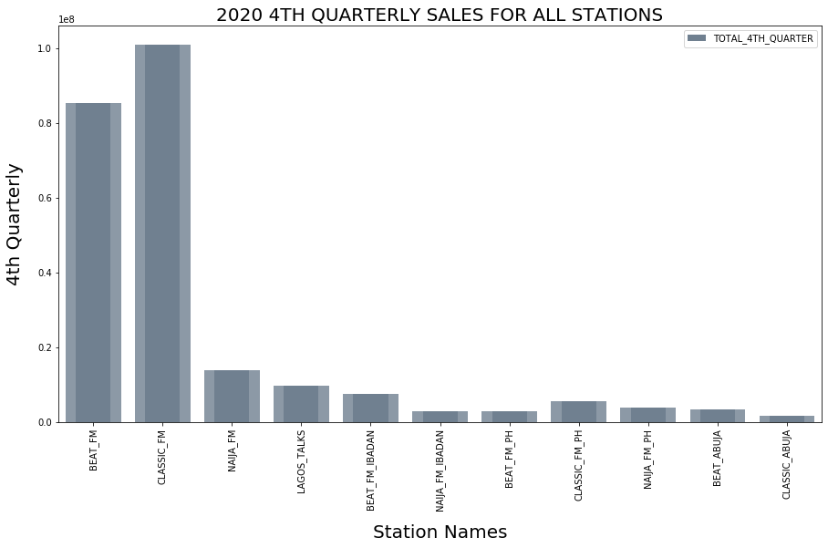

```python
sales2020.plot.bar(x="STATION_NAMES", y="TOTAL_4TH_QUARTER", figsize = (15,8), color = 'slategrey');
plt.bar(sales2020['STATION_NAMES'], sales2020['TOTAL_4TH_QUARTER'], color = 'slategrey', alpha = 0.8);
plt.title('2020 4TH QUARTERLY SALES FOR ALL STATIONS', fontsize = 20);
plt.xlabel('Station Names', fontsize = 20, labelpad=15);
plt.ylabel('4th Quarterly', fontsize = 20, labelpad=15);
```

## 2020 SALES BY LOCATIONS

> Here we visualized each sale by locations (LAGOS, IBADAN, PORT-HARCOURT, AND ABUJA)for each station across the board. Our observation for the Lagos location shows that CLASSIC FM Lagos sales were much more outstanding than the rest stations in Lagos. For Ibadan location BEAT FM Ibadan performed better than NAIJA FM Ibadan. For the Port-Harcourt location NAIJA FM PH edge other stations. In Abuja location BEAT FM Abuja also performed better than CLASSIC FM Abuja.

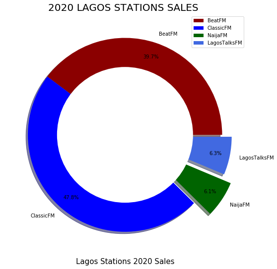

```python
my_labels=['BeatFM','ClassicFM','NaijaFM','LagosTalksFM']
my_colors=['darkred','blue','darkgreen','royalblue']
explode = (0, 0, 0.2, 0.1)
lagos_sales.plot.pie(y='LOCATION TOTAL SALES',autopct='%1.1f%%',figsize=(9,9),colors=my_colors,labels=my_labels,explode=explode, shadow=True, pctdistance=0.85);
plt.title('2020 LAGOS STATIONS SALES ', fontsize = 20);
plt.xlabel('Lagos Stations 2020 Sales', fontsize = 15);
plt.ylabel('');
#draw circle
centre_circle = plt.Circle((0,0),0.70,fc='white');
fig = plt.gcf();
fig.gca().add_artist(centre_circle);
```

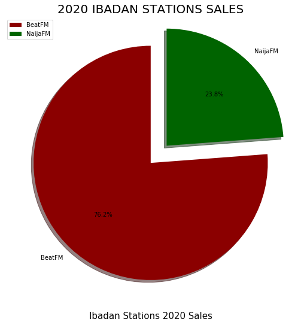

```python
my_labels=['BeatFM','NaijaFM']
my_colors=['darkred','darkgreen']
explode = (0, 0.2)
ibadan_sales.plot.pie(y='LOCATION TOTAL SALES',autopct='%1.1f%%',figsize=(9,9),labels=my_labels,colors=my_colors,explode=explode,shadow=True, startangle=90);
plt.title('2020 IBADAN STATIONS SALES', fontsize = 20);
plt.xlabel('Ibadan Stations 2020 Sales', fontsize = 15);
plt.ylabel('');
```

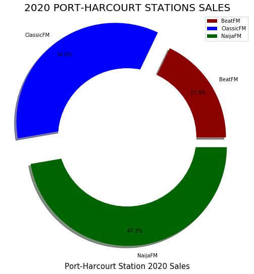

```python
my_labels=['BeatFM','ClassicFM','NaijaFM']
my_colors=['darkred','blue','darkgreen']
explode = (0, 0.2, 0.1)
ph_sales.plot.pie(y='LOCATION TOTAL SALES',autopct='%1.1f%%',figsize=(9,9),colors=my_colors,labels=my_labels,explode=explode, shadow=True, pctdistance=0.85);
plt.title('2020 PORT-HARCOURT STATIONS SALES', fontsize = 20);
plt.xlabel('Port-Harcourt Station 2020 Sales', fontsize = 15);
plt.ylabel('');
#draw circle
centre_circle = plt.Circle((0,0),0.70,fc='white');
fig = plt.gcf();
fig.gca().add_artist(centre_circle);
```

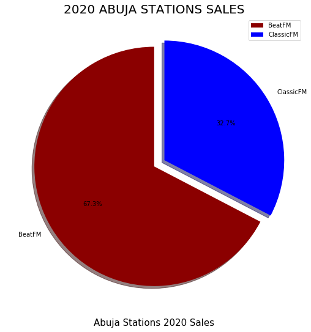

```python
my_labels=['BeatFM','ClassicFM']
my_colors=['darkred','blue']
explode = (0, 0.1)
abuja_sales.plot.pie(y='LOCATION TOTAL SALES',autopct='%1.1f%%',figsize=(9,9),labels=my_labels,colors=my_colors, explode=explode,shadow=True, startangle=90);
plt.title('2020 ABUJA STATIONS SALES', fontsize = 20);
plt.xlabel('Abuja Stations 2020 Sales', fontsize = 15);
plt.ylabel('');
```

## 2020 AVERAGE SALES PER YEAR

> We find the average sales for the year 2020 on all stations across the board. We have observed CLASSIC FM Lagos has an average sales of 24,126,090.00. BEAT FM Lagos has an average sales of 20,046,060.00. LagosTalks has an average sales of 3,194,836.00. Also, CLASSIC FM Abuja has the lowest average sales of 445,397.60.

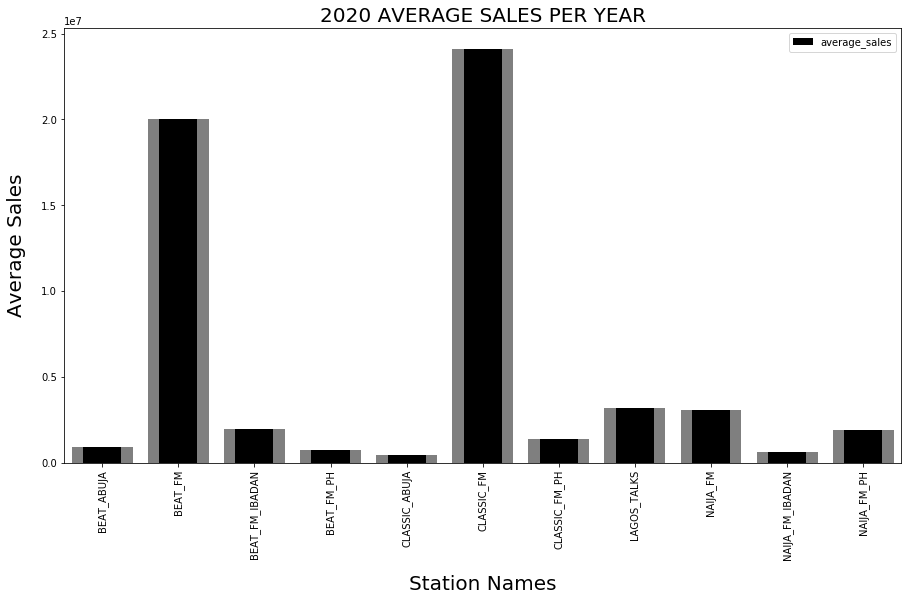

```python
avg_salesnew1.plot.bar(x="STATION_NAMES", y="average_sales", figsize = (15,8), color = 'black')
plt.bar(avg_salesnew1['STATION_NAMES'], avg_salesnew1['average_sales'], color = 'black', alpha = 0.5);
plt.title('2020 AVERAGE SALES PER YEAR', fontsize = 20);
plt.xlabel('Station Names', fontsize = 20, labelpad=15);
plt.ylabel('Average Sales', fontsize = 20, labelpad=15);
```

## Conclusion

> The total sales for the year 2020 are 700,171,559.74. CLASSIC FM Lagos's total sales for the year 2020 is 289,513,122.65 and BEAT FM Lagos's total sales for the year 2020 is 240,552,741.47. The remaining stations such as LAGOSTALKS FM, NAIJA FM Lagos, BEAT FM Ibadan, NAIJA FM Ibadan, BEAT FM PH, CLASSIC FM PH, NAIJA FM PH, BEAT FM Abuja, and CLASSIC FM Abuja all shares the total sales of 170,105,695.62 for the year 2020.